# Guided_Project_Recent_Grads

GUIDED PROJECT FROM DATAQUEST Part of the course Exploratory Data Visualization

Last updated: November 30, 2017

```python
# Pre-Analysis Activities

% matplotlib inline
import pandas as pd

recent_grads = pd.read_csv("recent-grads.csv")

# Displaying row 0 of the dataframe
print("FIRST ROW OF THE DATA SET")
recent_grads.iloc[0]
```

```
FIRST ROW OF THE DATA SET
```

```
Rank                                        1
Major_code                               2419
Major                   PETROLEUM ENGINEERING
Total                                    2339
Men                                      2057
Women                                     282
Major_category                    Engineering
ShareWomen                           0.120564
Sample_size                                36
Employed                                 1976
Full_time                                1849
Part_time                                 270
Full_time_year_round                     1207
Unemployed                                 37
Unemployment_rate                   0.0183805
Median                                 110000
P25th                                   95000
P75th                                  125000
College_jobs                             1534
Non_college_jobs                          364
Low_wage_jobs                             193
Name: 0, dtype: object
```

```python
# Displaying the first five rows of the dataframe
print("FIRST FIVE ROWS OF THE DATA SET")
recent_grads.head()
```

```
FIRST FIVE ROWS OF THE DATA SET
```

|  | Rank | Major_code | Major | Total | Men | Women | Major_category | ShareWomen | Sample_size | Employed | ... | Part_time | Full_time_year_round | Unemployed | Unemployment_rate | Median | P25th | P75th | College_jobs | Non_college_jobs | Low_wage_jobs |
| --- | --- | --- | --- | --- | --- | --- | --- | --- | --- | --- | --- | --- | --- | --- | --- | --- | --- | --- | --- | --- | --- |
| 0 | 1 | 2419 | PETROLEUM ENGINEERING | 2339.0 | 2057.0 | 282.0 | Engineering | 0.120564 | 36 | 1976 | ... | 270 | 1207 | 37 | 0.018381 | 110000 | 95000 | 125000 | 1534 | 364 | 193 |
| 1 | 2 | 2416 | MINING AND MINERAL ENGINEERING | 756.0 | 679.0 | 77.0 | Engineering | 0.101852 | 7 | 640 | ... | 170 | 388 | 85 | 0.117241 | 75000 | 55000 | 90000 | 350 | 257 | 50 |
| 2 | 3 | 2415 | METALLURGICAL ENGINEERING | 856.0 | 725.0 | 131.0 | Engineering | 0.153037 | 3 | 648 | ... | 133 | 340 | 16 | 0.024096 | 73000 | 50000 | 105000 | 456 | 176 | 0 |
| 3 | 4 | 2417 | NAVAL ARCHITECTURE AND MARINE ENGINEERING | 1258.0 | 1123.0 | 135.0 | Engineering | 0.107313 | 16 | 758 | ... | 150 | 692 | 40 | 0.050125 | 70000 | 43000 | 80000 | 529 | 102 | 0 |
| 4 | 5 | 2405 | CHEMICAL ENGINEERING | 32260.0 | 21239.0 | 11021.0 | Engineering | 0.341631 | 289 | 25694 | ... | 5180 | 16697 | 1672 | 0.061098 | 65000 | 50000 | 75000 | 18314 | 4440 | 972 |

5 rows × 21 columns

```python
# Displaying the last five rows of the dataframe
print("LAST FIVE ROWS OF THE DATA SET")
recent_grads.tail()
```

```
LAST FIVE ROWS OF THE DATA SET
```

|  | Rank | Major_code | Major | Total | Men | Women | Major_category | ShareWomen | Sample_size | Employed | ... | Part_time | Full_time_year_round | Unemployed | Unemployment_rate | Median | P25th | P75th | College_jobs | Non_college_jobs | Low_wage_jobs |
| --- | --- | --- | --- | --- | --- | --- | --- | --- | --- | --- | --- | --- | --- | --- | --- | --- | --- | --- | --- | --- | --- |
| 168 | 169 | 3609 | ZOOLOGY | 8409.0 | 3050.0 | 5359.0 | Biology & Life Science | 0.637293 | 47 | 6259 | ... | 2190 | 3602 | 304 | 0.046320 | 26000 | 20000 | 39000 | 2771 | 2947 | 743 |
| 169 | 170 | 5201 | EDUCATIONAL PSYCHOLOGY | 2854.0 | 522.0 | 2332.0 | Psychology & Social Work | 0.817099 | 7 | 2125 | ... | 572 | 1211 | 148 | 0.065112 | 25000 | 24000 | 34000 | 1488 | 615 | 82 |
| 170 | 171 | 5202 | CLINICAL PSYCHOLOGY | 2838.0 | 568.0 | 2270.0 | Psychology & Social Work | 0.799859 | 13 | 2101 | ... | 648 | 1293 | 368 | 0.149048 | 25000 | 25000 | 40000 | 986 | 870 | 622 |
| 171 | 172 | 5203 | COUNSELING PSYCHOLOGY | 4626.0 | 931.0 | 3695.0 | Psychology & Social Work | 0.798746 | 21 | 3777 | ... | 965 | 2738 | 214 | 0.053621 | 23400 | 19200 | 26000 | 2403 | 1245 | 308 |
| 172 | 173 | 3501 | LIBRARY SCIENCE | 1098.0 | 134.0 | 964.0 | Education | 0.877960 | 2 | 742 | ... | 237 | 410 | 87 | 0.104946 | 22000 | 20000 | 22000 | 288 | 338 | 192 |

5 rows × 21 columns

```python
# Cleaning - Dropping rows with missing values
raw_data_count = len(recent_grads)

recent_grads = recent_grads.dropna(axis = 0)

cleaned_data_count = len(recent_grads)

print("No. of rows (uncleaned): ", raw_data_count)
print("No. of rows (cleaned): ", cleaned_data_count)
```

```
No. of rows (uncleaned):  173
No. of rows (cleaned):  172
```

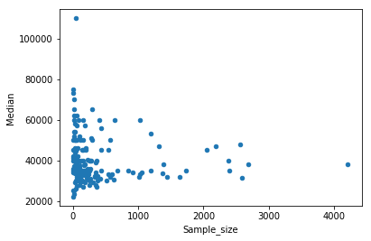

```python
# Analysis 1: Comparing Sample_size to Median
# Aims to answer the question
# Do students in more popular majors make more money?

recent_grads.plot(x = "Sample_size", y = "Median", kind = "scatter")
```

BACKGROUND

The column "Sample_size" is the number of students enrolled in a particular major. For example, the major "ZOOLOGY" has a sample size of 47. This simply means that 47 Zoology majors participated in the survey. Roughly, the sample size can be a measure of popularity with respect to the majors. The more students for a particular major, the more popular it is. Conversely, the less students for a particular major, the less popular it is.

The column "Median" is the median salary of full-time, year-round workers for a particular major. Using the zoology example again, the median salary for zoology majors is 26K.

INTERPRETATION

Based on the results of this survey, it would seem that students of more popular majors are less likely to make more money than those of less popular majors.

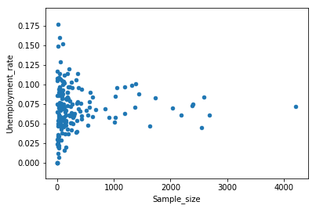

```python
# Analysis 2: Comparing Sample_size to Unemployment_rate

recent_grads.plot(x = "Sample_size", y = "Unemployment_rate", kind = "scatter")
```

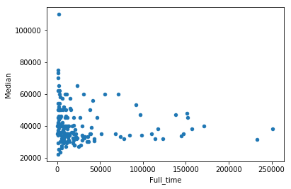

```python
# Analysis 3: Comparing Full_time and Median
# Aims to answer the question
# Is there any link between the number of full-time employees and median salary?

recent_grads.plot(x = "Full_time", y = "Median", kind = "scatter")
```

BACKGROUND

The column "Full_time" is the number of students of a particular major who are employed in jobs requiring them to work 35 hours or more.

The column "Median" is the median salary of full-time, year-round workers for a particular major.

INTERPRETATION

Based on the plot above, it can be seen that the data points are denser at the smaller number of full time employees, but the corresponding median salary ranges from 20K to around 80K.

In general (without considering the accurate calculation of correlation), it would seem that the data tries to converge to a median value of somewhere in between 25K and 40K. In this sense, one could say that there is a link between the number of full time employees per major and the corresponding median salary. But because the data points can be scattered with respect to the Full_time column value (i.e., one full_time value can have multiple possible Median value), this link can be considered weak.

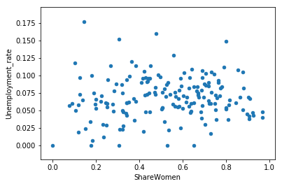

```python
# Analysis 4: Comparing ShareWomen and Unemployment_rate

recent_grads.plot(x = "ShareWomen", y = "Unemployment_rate", kind = "scatter")
```

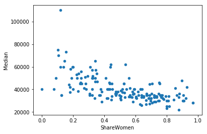

```python
# Analysis 5: Comparing ShareWomen and Median
# Aims to answer the question
# Do students that majored in subjects that were majority female
# make more money?

recent_grads.plot(x = "ShareWomen", y = "Median", kind = "scatter")
```

BACKGROUND

The column ShareWomen is the ratio of women students to the total number of students in a particular major.

The column "Median" is the median salary of full-time, year-round workers for a particular major.

INTERPRETATION

While the data points are still seen to be scattered, it is clear that the points tend to trace a line sloping downwards as the number of ShareWomen increase in a particular major. This indicates that as the major becomes more popular with women (i.e., the higher the ShareWomen size), the median salary tends to decrease. Based on the data, it can be said that students who majored in subjects where majority are female do not make more money than those who majored in subjects that have lesser female students.

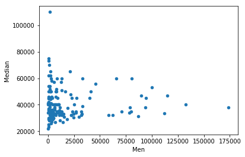

```python
# Analysis 6: Comparing Men and Median

recent_grads.plot(x = "Men", y = "Median", kind = "scatter")
```

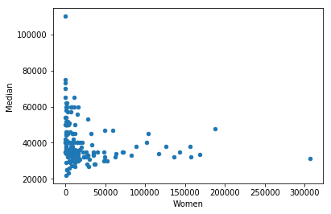

```python
# Analysis 7: Comparing Women and Median

recent_grads.plot(x = "Women", y = "Median", kind = "scatter")
```

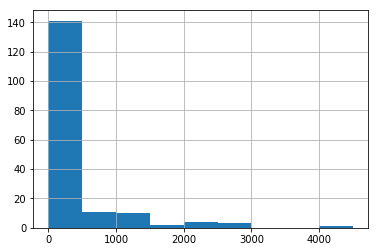

```python
# Analysis 8: Histogram for Sample_size

recent_grads["Sample_size"].hist(bins = 9, range =(0,4500))
```

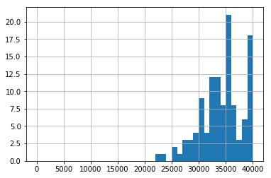

```python
# Analysis 9: Histogram for Median
# Aims to answer the question:
# What's the most common median salary range?

recent_grads["Median"].hist(bins = 40, range = (0, 40000))
```

```python
# Determining the most common salary range

n = 36
median_interval = 40000 / 40

max_range = n*median_interval
min_range = max_range - median_interval

print("MOST COMMON MEDIAN SALARY RANGE")
print("(", min_range, ", ", max_range, ")")
```

```
MOST COMMON MEDIAN SALARY RANGE
( 35000.0 ,  36000.0 )
```

The histogram for the median was created using 40 bins with a range from 0 to 40K. From the histogram, it was found that the highest bar was the 36th bar (n = 36). The interval for each range is 40K / 40 (highest value for the range divided by the number of bins). Thus, the range for the highest bar is calculated as:

maximum range = n X interval

minimum range = maximum range - interval

This is the formula used for the most common median salary range calculation.

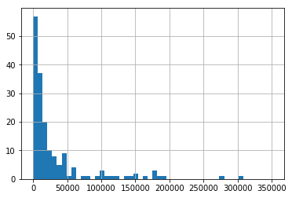

```python
# Analysis 10: Histogram for Employed

recent_grads["Employed"].hist(bins = 50, range = (0, 350000))
```

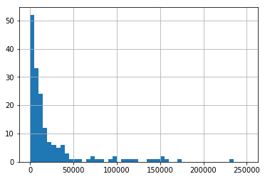

```python
# Analysis 11: Histogram for Full_time

recent_grads["Full_time"].hist(bins = 50, range = (0, 250000))
```

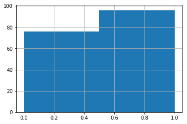

```python
# Analysis 12: Histogram for ShareWomen
# Aims to answer the question
# What percent of majors are predominantly male? Predominantly female?

recent_grads["ShareWomen"].hist(bins = 2, range = (0, 1))
```

```python
# Calculating percentages - based on the histogram

total = 75 + 95
male_dom = (75 / total)*100
female_dom = (95 / total)*100

print("PERCENT DOMINATION BASED ON HISTOGRAM")
print("male: ", male_dom, "%")
print("female: ", female_dom, "%")

# Calculating percentages - based on actual count
gender_domination = recent_grads["ShareWomen"]
male_dom_bool = gender_domination < 0.5
male_dom_series = gender_domination[male_dom_bool]
female_dom_series = gender_domination[male_dom_bool == False]

male_dom_total = len(male_dom_series)
female_dom_total = len(female_dom_series)

male_dom_percent_actual = (male_dom_total / cleaned_data_count)*100
female_dom_percent_actual = (female_dom_total / cleaned_data_count)*100

print()
print("PERCENT DOMINATION BASED ON ACTUAL COUNT")
print("male: ", male_dom_percent_actual, "%")
print("female: ", female_dom_percent_actual, "%")
```

```
PERCENT DOMINATION BASED ON HISTOGRAM
male:  44.11764705882353 %
female:  55.88235294117647 %

PERCENT DOMINATION BASED ON ACTUAL COUNT
male:  44.18604651162791 %
female:  55.81395348837209 %
```

BACKGROUND

ShareWomen is the ratio of women students to the total number of students in a particular major. Using Zoology as an example, the number of women majoring in Zoology is 5359 while the total number of students majoring in Zoology is 8409. Dividing 5359 by 8409, we get 0.63729. This ratio is the ShareWomen for Zoology.

DEFINITIONS

Predominantly Female => Sharewomen with a value of 0.5 to 1

Predominantly Male => Sharewomen with a value of 0 to 0.49

INTERPRETATION

From the histogram for ShareWomen, the range from 0 to 0.49 has a frequency of approximatly 75 while the Sharewomen from 0.5 to 1 has a frequency of approximately 95. Based on Histogram approximations, the percent of majors predominantly male is 44.12% while the percent majors predominantly female is 55.88%.

Actual values may be calculated through manipulations of the column ShareWomen. The actual values were found to be close to the approximation - 44.19% for males and 55.81% for females.

FINAL OBSERVATIONS

While histogram approximations are not 100% accurate, it gives a quicker way of evaluating values.

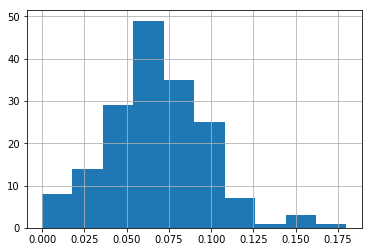

```python
# Analysis 13: Histogram for Unemployment_rate

recent_grads["Unemployment_rate"].hist(bins = 10, range = (0, 0.18))
```

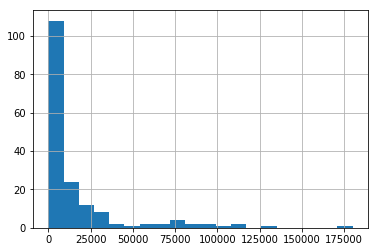

```python
# Analysis 14: Histogram for Men

recent_grads["Men"].hist(bins = 20, range = (0, 180000))
```

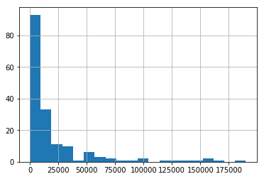

```python
# Analysis 15: Histogram for Women

recent_grads["Women"].hist(bins = 20, range = (0, 190000))
```

```
array([[<matplotlib.axes._subplots.AxesSubplot object at 0x000002482E5FFE10>,
        <matplotlib.axes._subplots.AxesSubplot object at 0x000002482E738710>]], dtype=object)
```

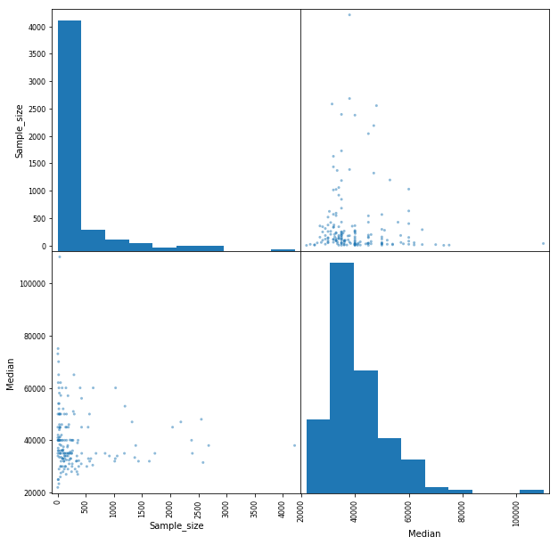

```python
# Analysis 16: Scatter plots and
# Histograms for Sample_size and Median
# Revisiting: Do students in more popular majors make more money?

from pandas.plotting import scatter_matrix

scatter_matrix(recent_grads[['Sample_size', 'Median']], figsize=(10,10))
```

The same observation is seen in the four plots above - as sample size increases, the range for the median decreases indicating that students in more popular majors do not make more money.

```
array([[<matplotlib.axes._subplots.AxesSubplot object at 0x000002482E7F19B0>,
        <matplotlib.axes._subplots.AxesSubplot object at 0x000002482E9F2278>]], dtype=object)
```

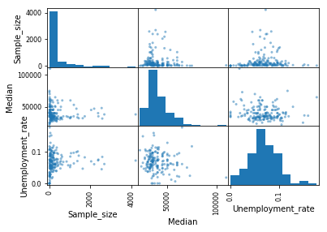

```python
# Analysis 17: Scatter plots and Histograms for
# Sample_size, Median and Unemployment_rate

scatter_matrix(recent_grads[["Sample_size", "Median", "Unemployment_rate"]])
```

```
array([[<matplotlib.axes._subplots.AxesSubplot object at 0x000002482E822F60>,
        <matplotlib.axes._subplots.AxesSubplot object at 0x000002482ECE2550>]], dtype=object)
```

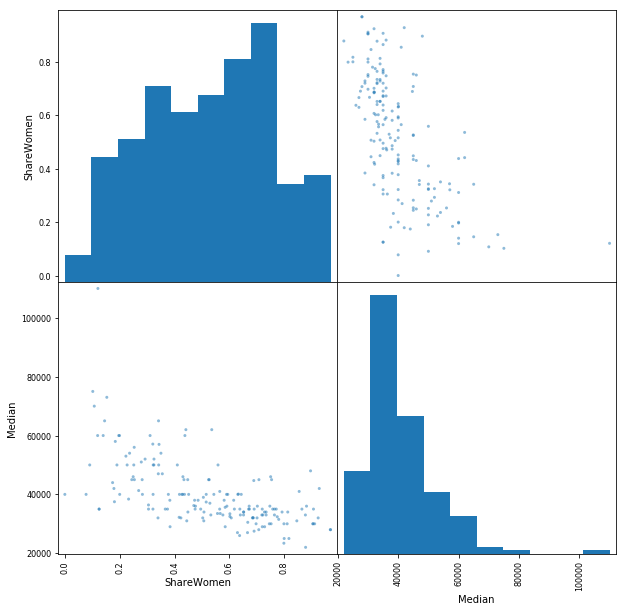

```python
# Analysis 18: Scatter plots and histograms for
# ShareWomen and Median
# Revisiting:
# Q1: Do students that majored in subjects that were
# majority female make more money?
# Q2: What's the most common median salary range?
# Q3: What percent of majors are predominantly male?
# Predominantly female?

scatter_matrix(recent_grads[["ShareWomen", "Median"]], figsize = (10, 10))
```

QUESTION 1

The same observation is seen in the four plots above - as ShareWomen increases, the median tends to decrease indicating that students majoring in subjects where majority are female do not make more money than students majoring in subjects where majority are not female.

QUESTION 2

Given the Histogram for Median having 10 bins (lower right plot), the most common median salary range is from 30000 to 40000.

```python
# Attempting to answer Question 3

sm_male = 0.4 + 0.45 + 0.5 + 0.75 + 0.6
sm_female = 0.7 + 0.8 + 0.95 + 0.37 + 0.38
sm_total = sm_male + sm_female

sm_male_percent = (sm_male / sm_total)*100
sm_female_percent = (sm_female / sm_total)*100

print("ESTIMATE FOR PERCENT DOMINATION")
print("male: ", sm_male_percent, "%")
print("female: ", sm_female_percent, "%")
```

```
ESTIMATE FOR PERCENT DOMINATION
male:  45.76271186440678 %
female:  54.23728813559322 %
```

ANSWER TO QUESTION 3

Based on the histogram of the default bin size for scatter_matrix, the percentage of majors in male dominated fields is 45.76% while for female dominated fields, the percentage is 54.23%.

The numbers are still near the actual values, but are less accurate.

```
array([[<matplotlib.axes._subplots.AxesSubplot object at 0x000002482ED742B0>,
        <matplotlib.axes._subplots.AxesSubplot object at 0x000002482EE6F668>]], dtype=object)
```

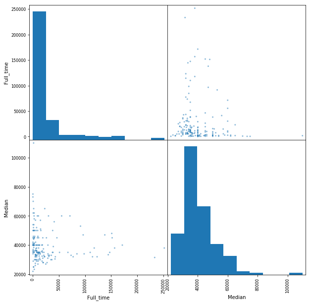

```python
# Analysis 19: Scatter plots and histograms for
# Full_time and median
# Revisiting: Is there any link between the number of full-time
# employees and median salary?

scatter_matrix(recent_grads[["Full_time", "Median"]], figsize = (10, 10))
```

While there is an indication that higher number of students having full-time employment indicates lower salary ranges, the link between the two variables is weak.

FINAL OBSERVATION scatter_matrix() is convenient because it allows display of multiple plots in one code line.

But unless the plots are customized according to the data displayed and the analysis required, it can be difficult to extract useful information from the plots.

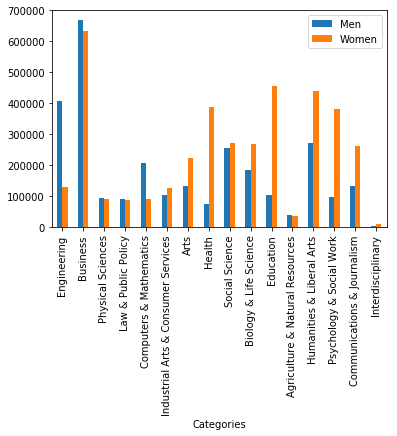

```python
# Analysis 20 - Suggested Next Steps
# Use a grouped bar plot to compare the number of men with women in each category of majors

# Grouping and summing the number of men and women per category
# End Result: Lists for category titles, number of men per category, number of women per category
category_list = recent_grads["Major_category"].unique().tolist()

def category_series(col_title, mother_data = recent_grads, categories = category_list):
    series_column = mother_data[col_title]
    col_per_category = []

    for cat in categories:
        bool = mother_data["Major_category"] == cat
        subset_column = series_column[bool]
        total = subset_column.sum()
        col_per_category.append(total)

    #series_col_per_category = pd.Series(data = col_per_category, index = categories)
    return(col_per_category)


men_per_category_list = category_series("Men")
women_per_category_list = category_series("Women")

# Creating a new dataframe
# End Result: A dataframe with columns for Categories, Number of men per category and Number of women per category
new_column_titles = ["Categories", "Men", "Women"]
bundled_data_list = [category_list, men_per_category_list, women_per_category_list]

dictionary_by_category = {}

for i, title in enumerate(new_column_titles):
    dictionary_by_category[title] = bundled_data_list[i]


df_by_category = pd.DataFrame(dictionary_by_category)


# Plotting the Data Set
# End Result: A grouped bar plot comparing the number of men and number of women per category
df_by_category.plot(x = "Categories", kind = "bar")
```

From the plot above, it can be seen that the most number of students are enrolled in Business, but the the number of male students are greater than the number of female students.

Judging by the very low heights of the bars, there are only a few students enrolled in interdisciplinary courses but the number of female students are greater than the number of male students.

Out of the 16 categories, 10 categories have female dominated fields. These fields are (in no particular order):

1. Industrial Arts & Consumer Services
2. Arts
3. Health
4. Social Science
5. Biology & Life Science
6. Education
7. Humanities & Liberal Arts
8. Psychology & Social Work
9. Communications & Journalism
10. Interdisciplinary Courses

Male dominated fields are (in no particular order):

1. Engineering
2. Business
3. Physical Sciences
4. Law & Policy
5. Computers & Mathematics
6. Agriculture & Natural Resources

```
count       172.000000
mean      40076.744186
std       11461.388773
min       22000.000000
25%       33000.000000
50%       36000.000000
75%       45000.000000
max      110000.000000
Name: Median, dtype: float64
```

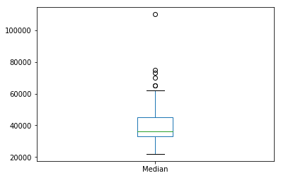

```python
# Analysis 21 - Suggested next steps
# Use a box plot to explore the distributions of median salaries and unemployment rate

# Box Plot for Median Salaries

recent_grads["Median"].plot(kind = "box")
recent_grads["Median"].describe()
```

The box plot for median salaries show that the minimum median salary is 22K. This minimum is the same as the minimum for the statistics derived using *.describe().

But because of the outliers, the maximum for the box plot is shown to be slightly above 60K. The median value is below 40K. The Q1 value is around or slightly above 30K while the Q3 value is slightly below 50K.

The plot is also skewed upwards indicating that the values within the upper half has a wider range in its values than the lower half.

```python
# Examining the outliers for Median Salaries

median_bool = recent_grads["Median"] > 62000
find_outliers = recent_grads[median_bool]

display((find_outliers))
```

|  | Rank | Major_code | Major | Total | Men | Women | Major_category | ShareWomen | Sample_size | Employed | ... | Part_time | Full_time_year_round | Unemployed | Unemployment_rate | Median | P25th | P75th | College_jobs | Non_college_jobs | Low_wage_jobs |
| --- | --- | --- | --- | --- | --- | --- | --- | --- | --- | --- | --- | --- | --- | --- | --- | --- | --- | --- | --- | --- | --- |
| 0 | 1 | 2419 | PETROLEUM ENGINEERING | 2339.0 | 2057.0 | 282.0 | Engineering | 0.120564 | 36 | 1976 | ... | 270 | 1207 | 37 | 0.018381 | 110000 | 95000 | 125000 | 1534 | 364 | 193 |
| 1 | 2 | 2416 | MINING AND MINERAL ENGINEERING | 756.0 | 679.0 | 77.0 | Engineering | 0.101852 | 7 | 640 | ... | 170 | 388 | 85 | 0.117241 | 75000 | 55000 | 90000 | 350 | 257 | 50 |
| 2 | 3 | 2415 | METALLURGICAL ENGINEERING | 856.0 | 725.0 | 131.0 | Engineering | 0.153037 | 3 | 648 | ... | 133 | 340 | 16 | 0.024096 | 73000 | 50000 | 105000 | 456 | 176 | 0 |
| 3 | 4 | 2417 | NAVAL ARCHITECTURE AND MARINE ENGINEERING | 1258.0 | 1123.0 | 135.0 | Engineering | 0.107313 | 16 | 758 | ... | 150 | 692 | 40 | 0.050125 | 70000 | 43000 | 80000 | 529 | 102 | 0 |
| 4 | 5 | 2405 | CHEMICAL ENGINEERING | 32260.0 | 21239.0 | 11021.0 | Engineering | 0.341631 | 289 | 25694 | ... | 5180 | 16697 | 1672 | 0.061098 | 65000 | 50000 | 75000 | 18314 | 4440 | 972 |
| 5 | 6 | 2418 | NUCLEAR ENGINEERING | 2573.0 | 2200.0 | 373.0 | Engineering | 0.144967 | 17 | 1857 | ... | 264 | 1449 | 400 | 0.177226 | 65000 | 50000 | 102000 | 1142 | 657 | 244 |

6 rows × 21 columns

Inspecting the outliers, it is observed that all outliers are in the Engineering major category. Ranking from the highest to the lowest median salary, the outlier majors are:

1. Petroleum Engineering
2. Mining & Mineral Engineering
3. Metallurgical Engineering
4. Naval Architecture & Marine Engineering
5. Chemical Engineering
6. Nuclear Engineering

The 6 majors listed above provide unusually high median salaries for their employees.

```
count      166.000000
mean     38766.265060
std       8824.034357
min      22000.000000
25%      33000.000000
50%      36000.000000
75%      44925.000000
max      62000.000000
Name: Median, dtype: float64
```

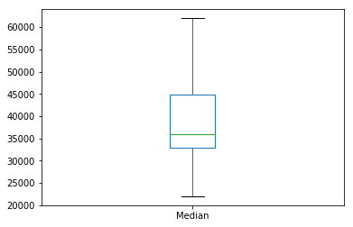

```python
# Replotting without the outliers

filtered_grads = recent_grads[median_bool == False]

filtered_grads["Median"].plot(kind = "box")
filtered_grads["Median"].describe()
```

Replotting the points without the outliers show that the statistics for *.describe() are the same as the box plot values for minimum (22K), median (36K), q1 (33K), q3 (44.925K) and maximum (62K).

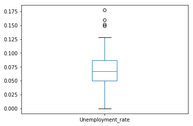

```python
# Box plot for unemployment rate

recent_grads["Unemployment_rate"].plot(kind = "box")
```

From the box plot above, it can be seen that there are 4 outlier values for this data set.

```python
# Removing the outliers

ur_bool = recent_grads["Unemployment_rate"] > 0.130
ur_outlier = recent_grads[ur_bool]

display(ur_outlier)
```

|  | Rank | Major_code | Major | Total | Men | Women | Major_category | ShareWomen | Sample_size | Employed | ... | Part_time | Full_time_year_round | Unemployed | Unemployment_rate | Median | P25th | P75th | College_jobs | Non_college_jobs | Low_wage_jobs |
| --- | --- | --- | --- | --- | --- | --- | --- | --- | --- | --- | --- | --- | --- | --- | --- | --- | --- | --- | --- | --- | --- |
| 5 | 6 | 2418 | NUCLEAR ENGINEERING | 2573.0 | 2200.0 | 373.0 | Engineering | 0.144967 | 17 | 1857 | ... | 264 | 1449 | 400 | 0.177226 | 65000 | 50000 | 102000 | 1142 | 657 | 244 |
| 84 | 85 | 2107 | COMPUTER NETWORKING AND TELECOMMUNICATIONS | 7613.0 | 5291.0 | 2322.0 | Computers & Mathematics | 0.305005 | 97 | 6144 | ... | 1447 | 4369 | 1100 | 0.151850 | 36400 | 27000 | 49000 | 2593 | 2941 | 352 |
| 89 | 90 | 5401 | PUBLIC ADMINISTRATION | 5629.0 | 2947.0 | 2682.0 | Law & Public Policy | 0.476461 | 46 | 4158 | ... | 847 | 2952 | 789 | 0.159491 | 36000 | 23000 | 60000 | 919 | 2313 | 496 |
| 170 | 171 | 5202 | CLINICAL PSYCHOLOGY | 2838.0 | 568.0 | 2270.0 | Psychology & Social Work | 0.799859 | 13 | 2101 | ... | 648 | 1293 | 368 | 0.149048 | 25000 | 25000 | 40000 | 986 | 870 | 622 |

4 rows × 21 columns

It will be interesting to note that Nuclear Engineering is one of the majors that has a relatively higher median salary, but it also has a relatively higher unemployment rate compared to the other majors.

```
count    168.000000
mean       0.065848
std        0.027109
min        0.000000
25%        0.050102
50%        0.066698
75%        0.085096
max        0.128426
Name: Unemployment_rate, dtype: float64
```

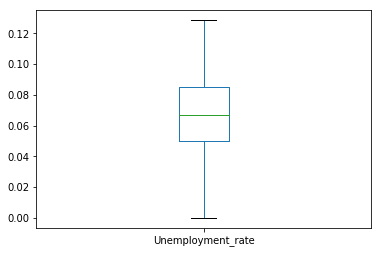

```python
ur_filtered_grads = recent_grads[ur_bool == False]

ur_filtered_grads["Unemployment_rate"].plot(kind = "box")
ur_filtered_grads["Unemployment_rate"].describe()
```

The following statistics describe the box plot above:

Minimum = 0.0

Q1 = 0.050102

Median = 0.066698

Q3 = 0.085096

Maximum = 0.128426

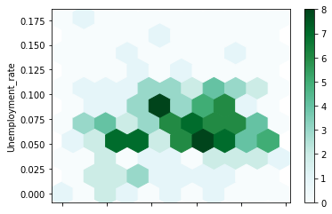

```python
# Analysis 22 - Suggested next steps
# Use a hexagonal bin plot to visualize the columns that had dense scatter plots from earlier in the project.

recent_grads.plot(x = "ShareWomen", y = "Unemployment_rate", kind = "hexbin", gridsize = 10)
```

Out of the 7 scatter plots, the scatter plot for ShareWomen and Unemployment_rate show plot points that are very scattered. A hexagonal bin plot is then applied to these two columns to investigate the relationship between ShareWomen and Unemployment_rate better.

The darker hexagons of the hexagonal bin plot indicate a linear relationship between ShareWomen and Unemployment_rate, where this linear relationship tends to trace a straight horizontal line. This straight horizontal line indicates that there is no correlation between ShareWomen and Unemployment_rate.